# Overview

# Interactions

**Name**

**Fare**

[figure not shown]

**PassengerId**

[figure not shown]

**Age**

[figure not shown]

**SibSp**

[figure not shown]

**Parch**

[figure not shown]

**Sex**

**Fare**

[figure not shown]

**PassengerId**

[figure not shown]

**Age**

[figure not shown]

**SibSp**

[figure not shown]

**Parch**

[figure not shown]

**Age**

**Fare**

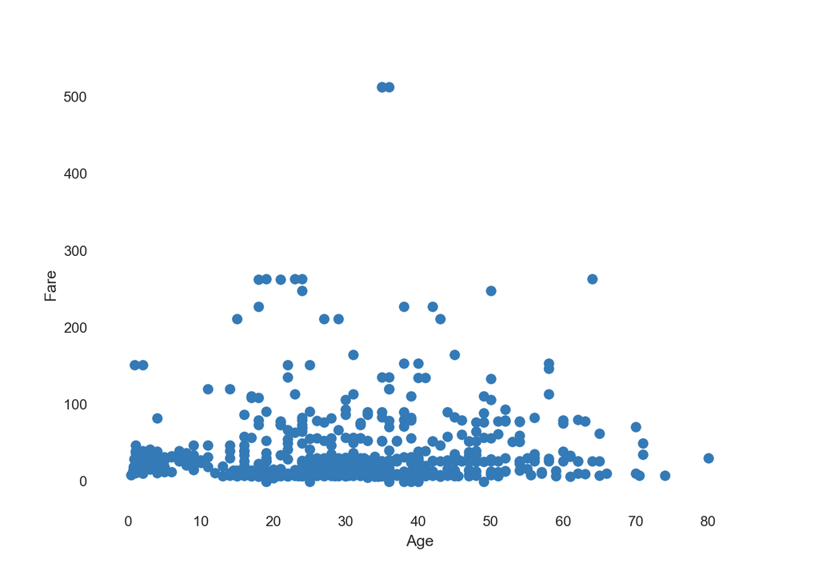

**PassengerId**

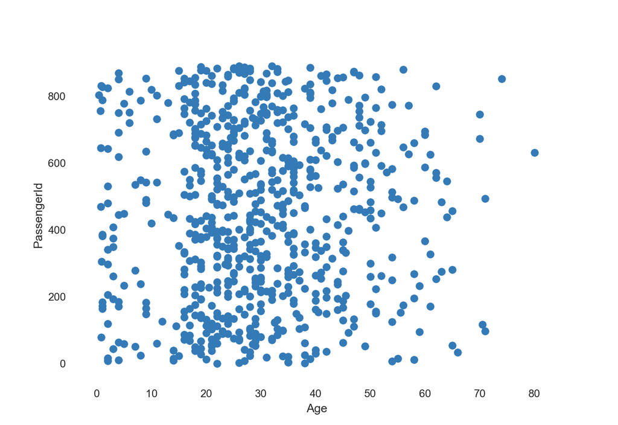

**Age**

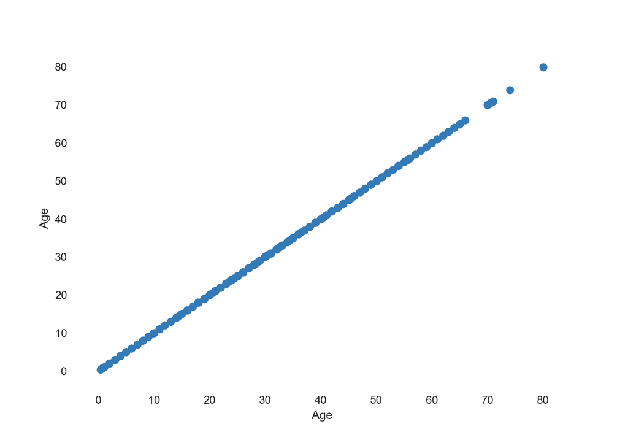

**SibSp**

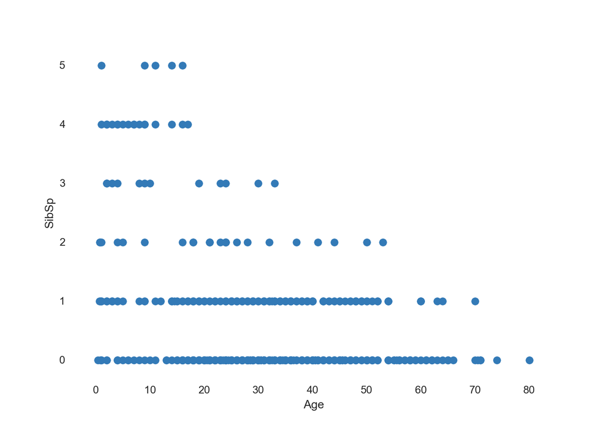

**Parch**

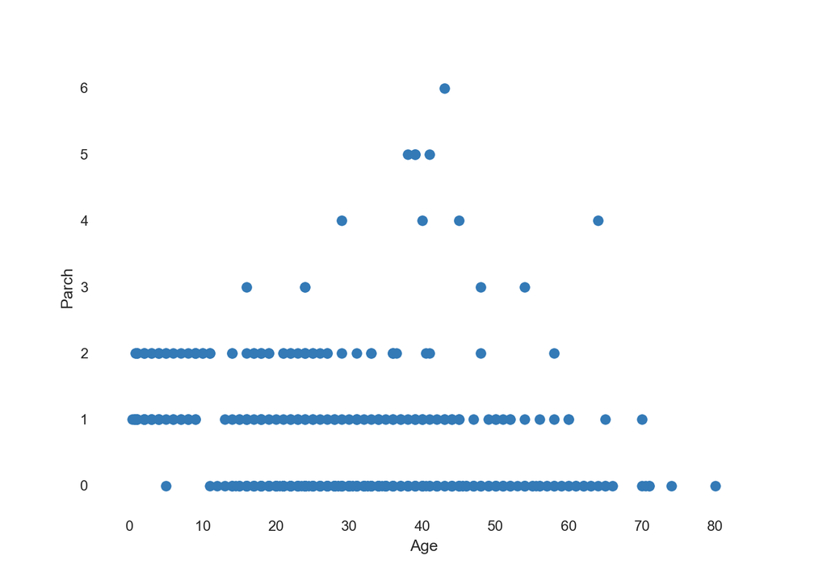